# Austrian presidential elections manipulated? Definitely not: Charts and Probabilities

Erich Neuwirth

August 27, 2016

## Load packages

```r
library(stringr)
library(ggplot2)
library(dplyr)
library(intubate)
library(magrittr)
```

## Get data and compute values needed

```r
load(file=file.path("Rdata","workdata.RData"))
```

```r
workdata %<>%
  mutate(Hofer_ant_u=Hofer_u/Tot_u,
         Hofer_ant_m=Hofer_m/Tot_m)
```

```r
workdata %>% select(Hofer_u,Hofer_m,Tot_u,Tot_m) %>%
  colSums() -> toterg
shiftneeded <- ceiling((toterg[3]+toterg[4])/2-(toterg[1]+toterg[2]))
hofer_behind <- (toterg[3]+toterg[4]) - 2 * (toterg[1]+toterg[2])
```

```r
workdata %>%
  select(incrim11,Tot_m,Hofer_m,Tot_u,Hofer_u) %>%
   group_by(incrim11) %>%
  summarise_each("sum") ->
  sums11
tot11m <- sums11[[1,2]]
hofer11m <- sums11[[1,3]]
hofer11u <- sums11[[1,5]]
tot11u <- sums11[[1,4]]
hoferneeds11 <- (hofer11m + shiftneeded)
```

## Charts

### Without modifications

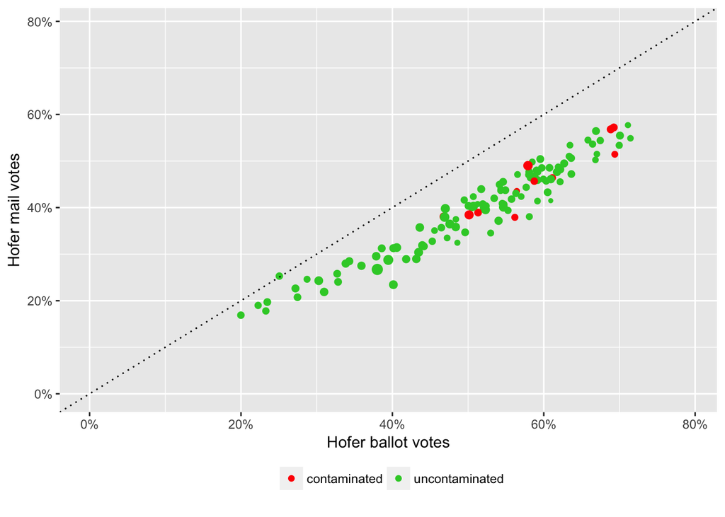

```r
mymax <- with(workdata,max(Hofer_ant_m,Hofer_ant_u)+0.075)
workdata %>%
  mutate(incrim=ifelse(incrim11=="beanst.","contaminated","uncontaminated")) %>%
  ggplot(aes(x=Hofer_ant_u,y=Hofer_ant_m,size=Tot_m,color=incrim)) +
  geom_point() +
  geom_abline(slope=1,intercept=0,linetype="dotted") +
  scale_size_continuous("",range=c(1,3),guide=FALSE) +
  scale_color_manual("",values=c("red","limegreen")) +
  scale_x_continuous("Hofer ballot votes",labels=scales::percent,
                     limits=c(0,mymax)) +
  scale_y_continuous("Hofer mail votes",
                     labels=scales::percent,limits=c(0,mymax)) +
  theme(legend.position="bottom") ->
  pic1
pic1
```

```r
pdf(file.path("TeX","pic1.pdf"),width=4,height=4.5)
pic1
dev.off()
```

### German labels, Villach marked

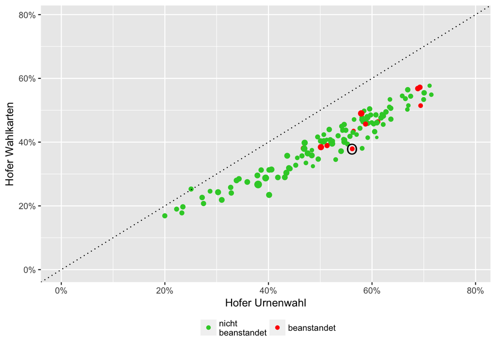

```r
villachdf <- workdata %>%
  filter(GKZ=="G20200")

mymax <- with(workdata,max(Hofer_ant_m,Hofer_ant_u)+0.075)
workdata %>%
  mutate(incrim=ifelse(incrim11=="beanst.","unsauber","sauber")) %>%
  ggplot(aes(x=Hofer_ant_u,y=Hofer_ant_m,size=Tot_m,color=incrim)) +
  geom_point() +
  geom_abline(slope=1,intercept=0,linetype="dotted") +
  geom_point(aes(x=Hofer_ant_u,y=Hofer_ant_m),data=villachdf,size=5,shape="O",inherit.aes=FALSE) +

  scale_size_continuous("Wahlkarten-\nstimmen",range=c(1,3),guide=FALSE) +
  scale_color_manual("",values=c("limegreen","red"),
                     labels=c("nicht\nbeanstandet","beanstandet")) +
  scale_x_continuous("Hofer Urnenwahl",labels=scales::percent,
                     limits=c(0,mymax)) +
  scale_y_continuous("Hofer Wahlkarten",
                     labels=scales::percent,limits=c(0,mymax)) +
  theme(legend.position="bottom") ->
  pic1d
pic1d
```

```r
pdf("pic1d.pdf",width=4,height=4.5)
pic1d
dev.off()
```

```r
system("open pic1d.pdf")
```

### Modifications in 11 districts

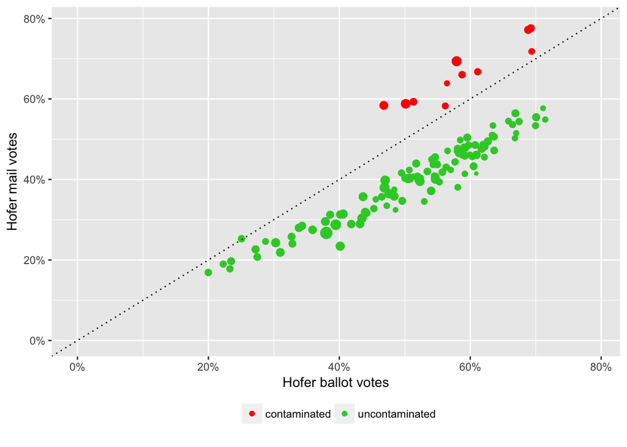

```r
mymax <- with(workdata,max(Hofer_ant_m,Hofer_ant_u)+0.075)

workdata %>%
  mutate(incrim=ifelse(incrim11=="beanst.","contaminated","uncontaminated")) %>%
#  mutate(incrim=factor(incrim,levels=c("contaminted","uncontaminated"))) %>%
  mutate(manipval=ifelse(incrim11=="beanst.",shiftneeded*Tot_m/tot11m,0)) %>%
  mutate(hh=(Hofer_m+manipval)/Tot_m) %>%
  ggplot(aes(x=Hofer_ant_u,y=hh,
             size=Tot_m,color=incrim)) +
  geom_point() +
  geom_abline(slope=1,intercept=0,linetype="dotted") +
  scale_size_continuous("",range=c(1,4),guide=FALSE) +
  scale_color_manual("",values=c("red","limegreen")) +
  scale_x_continuous("Hofer ballot votes",labels=scales::percent,
                     limits=c(0,mymax)) +
  scale_y_continuous("Hofer mail votes",
                     labels=scales::percent,limits=c(0,mymax)) +
    theme(legend.position="bottom") ->
  pic11
pic11
```

```r
pdf(file.path("TeX","pic11.pdf"),width=4,height=4.5)
pic11
dev.off()
```

### Modifications in 11 districts, German

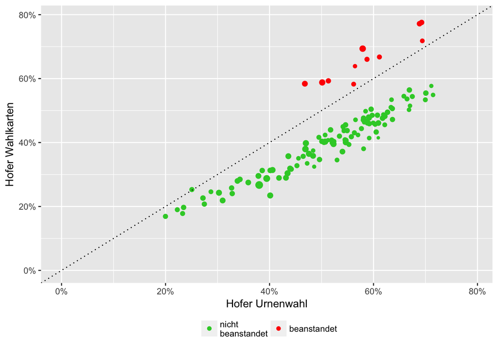

```r
mymax <- with(workdata,max(Hofer_ant_m,Hofer_ant_u)+0.075)

workdata %>%
  mutate(incrim=ifelse(incrim11=="beanst.","unsauber","sauber")) %>%
  mutate(manipval=ifelse(incrim11=="beanst.",shiftneeded*Tot_m/tot11m,0)) %>%
  mutate(hh=(Hofer_m+manipval)/Tot_m) %>%
  ggplot(aes(x=Hofer_ant_u,y=hh,
             size=Tot_m,color=incrim)) +
  geom_point() +
  geom_abline(slope=1,intercept=0,linetype="dotted") +

  scale_size_continuous("Wahlkarten-\nstimmen",range=c(1,3),guide=FALSE) +
  scale_color_manual("",values=c("limegreen","red"),
                     labels=c("nicht\nbeanstandet","beanstandet")) +
  scale_x_continuous("Hofer Urnenwahl",labels=scales::percent,
                     limits=c(0,mymax)) +
  scale_y_continuous("Hofer Wahlkarten",
                     labels=scales::percent,limits=c(0,mymax)) +
    theme(legend.position="bottom") ->
  pic11d
pic11d
```

```r
pdf("pic11d.pdf",width=4,height=4.5)
pic11d
dev.off()
```

```r
system("open pic11d.pdf")
```

## Computing probabilities for changing election outcome in different scenarios

### Linear model with 11 districts removed

```r
workdata %>% filter(!(incrim11 == "beanst.")) %>%
  ntbt_lm(Hofer_m ~ Hofer_u - 1,weights=1/Tot_m) ->
  model11
```

### Data frame for prediction sum of 11 districts

```r
preddf11 <- data.frame(Hofer_u=hofer11u,Tot_m=tot11m)
```

### Auxiliary function

`predict.lm` computes prediction intervals for given confidence levels. Our problem is the other way round, we compute the probability od the prediction exceeding a given target value.

To do this, we compute a prediction interval using the classical prediction estimator for linear models build into R for the conficence level corresponding to the confindence interval <-1,1> for the t-distribution with the model degrees of freedom. Then, we extract the value by which the t-distribution for this prediction has been rescaled, and use this scale value to compute the probability for a given prediction interval width.

```r
find_prob_pred_geq <- function(model,preddf,targetval){
  tprob <- 2*pt(1,df.residual(model))-1
  pred <- predict.lm(model,preddf,interval="prediction",weights=~1/Tot_m,level=tprob)
  predscale <- (pred[1]-pred[2])
  res <- 1-pt((targetval-pred[1])/predscale,df.residual(model))
  names(res) <- NULL
  res
}
```

## Probability for sum of 11 districts changing election outcome, model without 11 districts

```r
myprob <- find_prob_pred_geq(model11,preddf11,hoferneeds11)
myprob %>% cat()
```

```
1.322065e-10
```

```r
printfixed <- function(x)sprintf("%.0f",x)
```

We can check that the the probability really gives the target value as limit of the confidence interval.

Hofer lost by 30863, and he has 34479 votes in the contaminated districts. So he needs 15432 more mail votes there, making for a total of 49911 mail votes in the contaminated districts.

Let us check the corresponding prediction confidence interval with probability 0.999999999736

```r
predict(model11,preddf11,interval="prediction",weights=~1/Tot_m, level=1-2*myprob)
```

```
       fit      lwr   upr
1 33401.16 16891.33 49911
```